# Mapping

# What I am trying to communicate

My mom is a nurse and always says there is a difference between having health care coverage and having access.

For this assignment we will look at barriers that could impact someone from better access to health care such as number of hospitals, number of doctors, and wait time to be seen at the hospital.

In addition to these three barriers will be compared against life expectancy at birth.

These data will inform the reader of potential delays to medical access medial in different states.

# Data Source

Data came from the following sources and was pre-processed in the Python files attaches to this repo.

### Hospital Count Per State

American Hospital Directory https://www.ahd.com/state_statistics.html

Data claims to be most up-to date based on last report but does not give dates. Most of the report seems to be financial records and as I am interested in number of hospitals a lag-time is acceptable.

### Life Expectancy at Birth Per State

CDC https://www.cdc.gov/nchs/pressroom/sosmap/life_expectancy/life_expectancy.htm

Data taken from 2020 census. Results may be more extreme due to the effects of the pandemic.

### Doctros per 1000k popupation per state

National Library of Medicine

https://www.ncbi.nlm.nih.gov/books/NBK569310/table/ch2.tab16/?report=objectonly

Data is from 2019.

### Average Wait Time at Hospital

Business Insider

https://www.businessinsider.com/how-long-it-takes-to-see-a-doctor-by-state-2016-3

This data is a little dated from 2016. We will proceed with using but take it with a grain of salt.

# Spatial Units Being Displayed

The states are the units being displayed.

# Decisions to Best Communicate the Data.

There were a few things I thought about to help formulate the data:

1. Remove regions not being shown (like DC) to keep scaling more accurate
2. Color scheme and theme should be the same. Readers should see the trend “darker color means better” access all plots.

# Read in Data

```r
library(dplyr)
```

```r
library(ggplot2)
library(ggdendro)
library(viridis)
map = map_data("state")
hospital_data = read.csv("hospital_count.csv", header = TRUE)
life_exp = read.csv("Life_Expectancy_at_Birth_by_State_corrected.csv", header = TRUE)
docs_per_cap = read.csv("docs_per_cap.csv", header = TRUE)
avg_wait_to_be_seen_at_hos = read.csv("average_time_to_see_doc_at_hos_corrected.csv", header = TRUE)

map1 = map_data("state") %>% left_join(hospital_data, by = c("region" = "state"))
map2 = map_data("state") %>% left_join(life_exp, by = c("region" = "STATE"))
map3 = map_data("state") %>% left_join(docs_per_cap, by = c("region" = "state"))
map4 = map_data("state") %>% left_join(avg_wait_to_be_seen_at_hos, by = c("region" = "STATE"))
```

```r
hos_counts_st = ggplot(data = map1, mapping = aes(x = long, y = lat,group = group, fill = hospital_count)) +
                geom_polygon(color="white") +
                ggdendro::theme_dendro() +
                scale_fill_viridis(option="magma", direction=-1) +
                guides(fill=guide_legend(title="Hospital Count")) +
                coord_map() +
                ggtitle("Number of Hospitals")
```

```r
life_exp_rate = ggplot(data = map2, mapping = aes(x = long, y = lat,group = group, fill = RATE)) +
                geom_polygon(color="white") +
                ggdendro::theme_dendro() +
                scale_fill_viridis(option="magma", direction=-1) +
                guides(fill=guide_legend(title="Life Expectancy at Birth")) +
                coord_map() +
                ggtitle("Life Expectancy at Birth")
```

```r
doc_per_100_k = ggplot(data = map3, mapping = aes(x = long, y = lat,group = group, fill = doc_per_100k)) +
                geom_polygon(color="white") +
                ggdendro::theme_dendro() +
                scale_fill_viridis(option="magma", direction=-1) +
                guides(fill=guide_legend(title="Doctors per Capita")) +
                coord_map() +
                ggtitle("Doctors Per 100k Population")
```

```r
hos_wait_time = ggplot(data = map4, mapping = aes(x = long, y = lat,group = group, fill = TIME)) +
                geom_polygon(color="white") +
                ggdendro::theme_dendro() +
                scale_fill_viridis(option="magma", direction=1) +
                guides(fill=guide_legend(title="Time (min)")) +
                coord_map() +
                ggtitle("Average Hospital Wait Time")
```

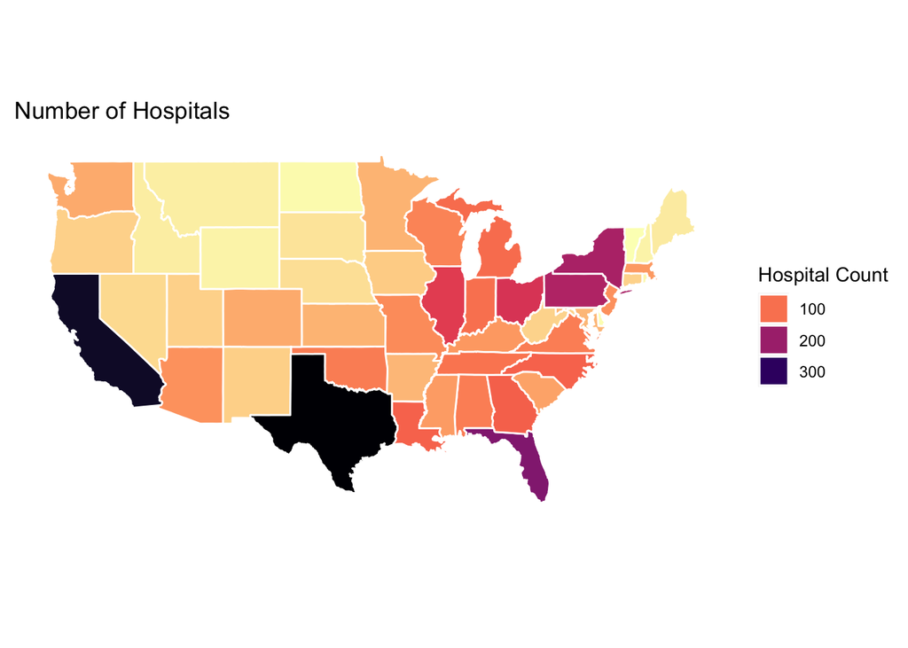

```r
hos_counts_st
```

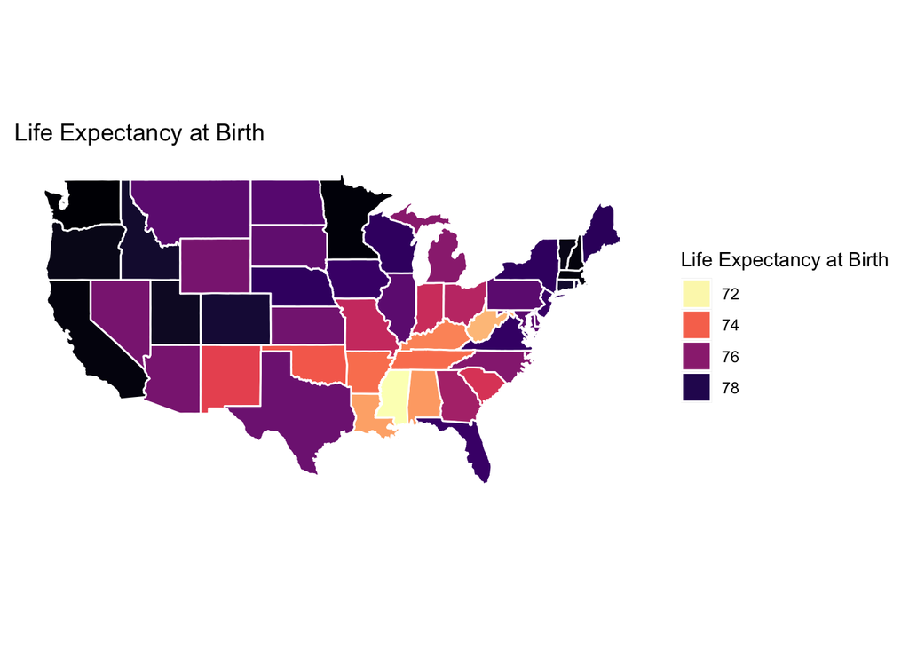

```r
life_exp_rate
```

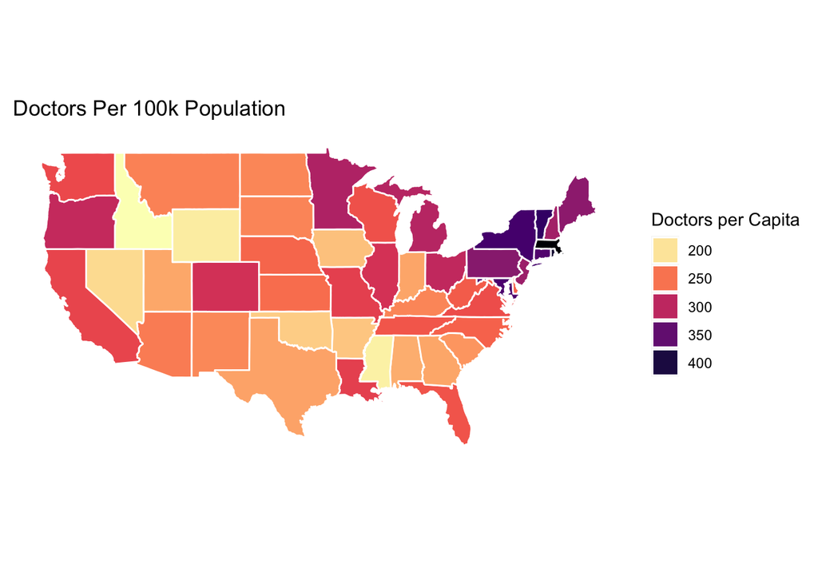

```r
doc_per_100_k
```

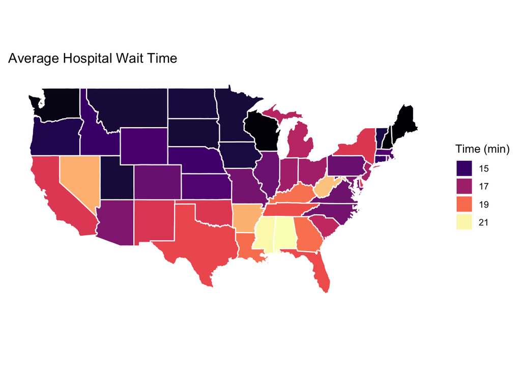

```r
hos_wait_time
```